# Propensity Score Matching|LAB Session

## Plot the results of the matching: Jitter plot

- Overall distribution of propensity scores
- The size of each point is proportional to the weight given to that unit.
- It it similar to the previous generated density plot

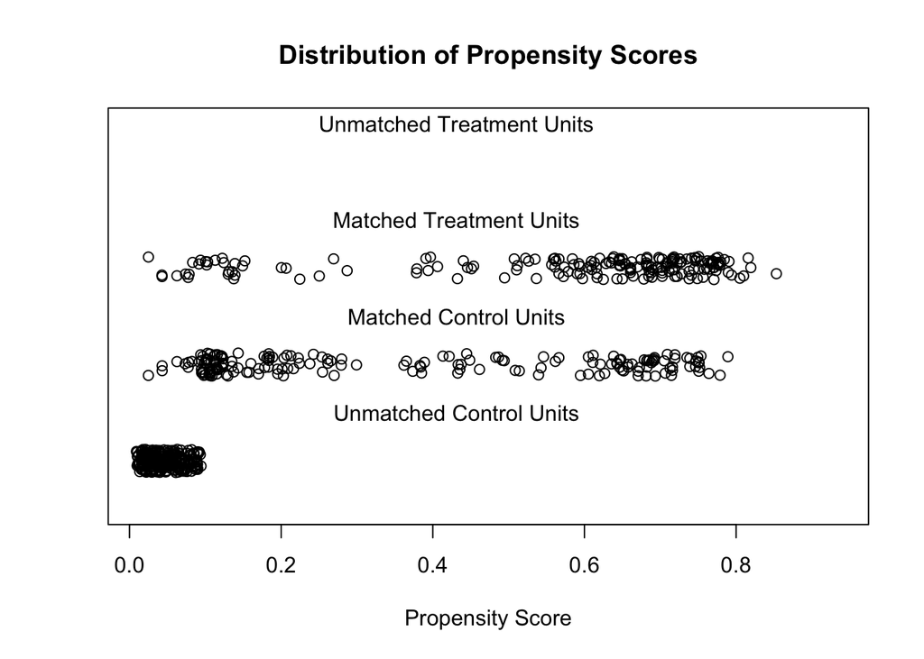

```r
plot(nearest,  type = "jitter",
  interactive = FALSE)
```

## Let’s extract the matched data

```r
matched_data <- match.data(nearest)
```

- We have only 370 observations left
- let’s now see how to get the ATT

## Estimation of the ATT: Non-Parametric

- Simple mean difference
- We don’t have a significance level
- Maybe we should run a paired t.test
- OR…

```r
mean(matched_data$re78[matched_data$treat == 1]) - mean(matched_data$re78[matched_data$treat == 0])
```

```
## [1] 908.2022
```

## Estimation of the ATT: Parametric

- OLS with dummy indicator

```r
regression_estimate <- lm(re78 ~ treat, data=matched_data)

stargazer(regression_estimate, type="html")
```

|  | *Dependent variable:* |
| --- | --- |
|  | re78 |
| treat1 | 908.202 |
|  | (730.724) |
| Constant | 5,440.941*** |
|  | (516.700) |
| Observations | 370 |
| R<sup>2</sup> | 0.004 |
| Adjusted R<sup>2</sup> | 0.001 |
| Residual Std. Error | 7,027.876 (df = 368) |
| F Statistic | 1.545 (df = 1; 368) |
| *Note:* | p<0.1; p<0.05; p<0.01 |

- DAMN! They are the same.
- **The results are not significant**
- Is it a problem?
- OLS is like running a paired t-test
- Easy answer: YES

## Estimation of the ATT: Parametric with control

- OLS with dummy indicator + controls
- Interpretation is different: The effect of the unemployment programs on real earnings, **keeping all the other variables constant**
- Conditional estimates VS Marginal estimates
- If we subscribe to the experimental logic and the matching is satisfactory
  - We should use marginal estimates
  - We should not condition on other variables
- **However**: many researchers use conditional effects in order to guard against variables that we were not able to balance with the matching technique
- So let’s re-run our estimates with race

```r
regression_estimate_conditional <- lm(re78 ~ treat+black + hispan, data=matched_data)
stargazer(regression_estimate_conditional, type="html")
```

|  | *Dependent variable:* |
| --- | --- |
|  | re78 |
| treat1 | 1,357.775* |
|  | (794.466) |
| black | -1,013.105 |
|  | (977.926) |
| hispan | 457.471 |
|  | (1,271.954) |
| Constant | 5,818.462*** |
|  | (827.639) |
| Observations | 370 |
| R<sup>2</sup> | 0.010 |
| Adjusted R<sup>2</sup> | 0.002 |
| Residual Std. Error | 7,026.247 (df = 366) |
| F Statistic | 1.239 (df = 3; 366) |
| *Note:* | p<0.1; p<0.05; p<0.01 |

- Uh, the results are now significant

## Estimation of the ATT: Parametric with unmatched dataset

- Let’s see what would be the results for a mean difference with the unmatched dataset

```r
regression_estimate_unmatched <- lm(re78 ~ treat, data=lalonde)

stargazer(regression_estimate_unmatched, type="html")
```

|  | *Dependent variable:* |
| --- | --- |
|  | re78 |
| treat1 | -635.026 |
|  | (657.137) |
| Constant | 6,984.170*** |
|  | (360.710) |
| Observations | 614 |
| R<sup>2</sup> | 0.002 |
| Adjusted R<sup>2</sup> | -0.0001 |
| Residual Std. Error | 7,471.134 (df = 612) |
| F Statistic | 0.934 (df = 1; 612) |
| *Note:* | p<0.1; p<0.05; p<0.01 |

- Quite impressive: We flipped the results.
- However: still not significant

# YOUR TURN

## Download the file exercise_jerusalem.rmd from my website